# Esperanza de vida al nacer

[figure not shown]

Cálculo de la esperanza de vida al nacer por comuna desde el 2006 al 2016

VE-CC

29-10-2021

# 1 La tabla de vida

Éste trabajo es una parte de uno que calculará el IDH según los patrones de las Naciones Unidas del 2006 al 2020.

Trabajaremos en particular sobre la esperanza de vida a nivel comunal

El gobierno de Chile no construye la esperanza de vida a nivel comunal. Es lo que haremos en éste trabajo.

## 1.1 La tabla de vida

La tabla de vida es la base para calcular la esperanza de vida.

Considere una “cohorte” de personas, por ejemplo, que nacieron el mismo día. Si pudiéramos seguirla desde el nacimiento hasta que todos mueran, podríamos registrar el número de individuos vivos en cada edad (digamos x) y el número que muere durante el año siguiente. La razón de éstos dos números es la probabilidad de morir a la edad x, generalmente denotada por q(x). Resulta que una vez que se conocen todas las q(x), la tabla de vida está completamente determinada.

En la práctica, estas “tablas de vida de cohortes” rara vez se utilizan, en parte porque los individuos deberían ser seguidos durante un período de hasta 100 años, y la tabla de vida resultante reflejaría condiciones históricas que tal vez ya no se apliquen. En cambio, generalmente se trabaja con un período o tabla de vida actual. Esto resume la experiencia de mortalidad de personas de todas las edades en un período corto, típicamente uno o tres años. Más precisamente, las probabilidades de muerte q(x) para cada edad x se calculan para ese corto período, a menudo utilizando información del censo recopilada a intervalos regulares (cada diez años en Chile). Luego, estas q(x) se aplican a una cohorte hipotética de 100.000 personas a lo largo de su vida para producir una tabla de vida.

A continuación se ofrece un ejemplo del Centro Nacional de Estadísticas de Salud de EEUU (1997).

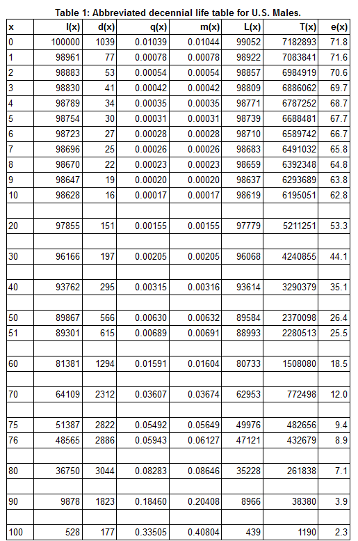

## 1.2 Definiciones

**x**: edad

$$l(x+1) = l(x)*exp[-m(x)]$$

siendo $l(0)$, la “base” de la tabla, establecida arbitrariamente en 100.000.

Por ejemplo:

$l(2) = l(1)*exp[-m(1)] = 98.961*exp(-0,00078) = 98883.84$

Corroboremos:

```r
98961*exp(-0.00078)
```

```
## [1] 98883.84
```

**m(x)**: la tasa de mortalidad a la edad x. Generalmente, estas cantidades **son la única entrada en la tabla de vida**. Es decir, todas las demás cantidades se determinan una vez que se especifican las $m(x)$.

Por definición, $m(x) = d(x)/L(x)$, ésto es, el número de muertes a la edad x dividido por el número de personas-años en riesgo a la edad x. Ten en cuenta que la tasa de mortalidad, $m(x)$, y la probabilidad de muerte, $q(x)$, no son idénticas. Durante un intervalo de un año, tendrán un valor cercano, pero $m(x)$ siempre será mayor.

**d(x)**: número de muertes en el intervalo $(x, x + 1)$ para personas vivas a la edad x, calculado como:

$$d(x) = l (x) - l (x + 1)$$

Por ejemplo, de las $l(50) = 89,867$ personas vivas a los 50 años,

$$d(50) = l (50) -l (51) = 89867 - 89301 = 566$$

murieron antes de los 51 años.

**q(x)**: probabilidad de morir a la edad x. También conocido como riesgo de muerte (específico por edad). Generalmente, éstos se obtienen usando la fórmula:

$$q(x) = 1 - exp [-m(x)]$$

bajo el supuesto de que la tasa de mortalidad instantánea, o la fuerza de la mortalidad, permanece constante a lo largo del intervalo de edad desde x hasta x + 1. Por construcción, q(x) también es igual a:

$$q(x) = d(x)/l(x)$$

Así, por ejemplo, q(50) = d(50)/l(50) = 566/89,867 = 0.00630.

**L(x)**: número total de años-persona vividos por la cohorte desde la edad x hasta x + 1. Ésta es la suma de los años vividos por las $l(x + 1)$ personas que sobreviven al intervalo y las $d(x)$ personas que mueren durante el intervalo. Los primeros contribuyen exactamente 1 año cada uno, mientras que los segundos contribuyen, en promedio, aproximadamente medio año, de modo que:

$$L (x) = l (x + 1) + 0.5 * d(x)$$

Esta aproximación supone que las muertes ocurren, en promedio, a la mitad del intervalo de edad x a x + 1. Esto es satisfactorio excepto a la edad de 0 años y la edad más avanzada, donde a menudo se utilizan otras aproximaciones; para más detalles, consulte el Centro Nacional de Estadísticas de Salud (1997) o Schoen (1988).

**T(x)**: número total de años-persona vividos por la cohorte desde la edad x hasta que todos los miembros de la cohorte han muerto. Esta es la suma de los números en la columna L(x) desde la edad x hasta la última fila de la tabla.

**e(x)**: la esperanza de vida (restante) de las personas vivas a la edad x, calculada como e(x) = T(x)/l(x). Por ejemplo, a los 50 años, la esperanza de vida es:

$$e(50) = T(50)/l(50) = 2,370,099/89,867 = 26,4.$$

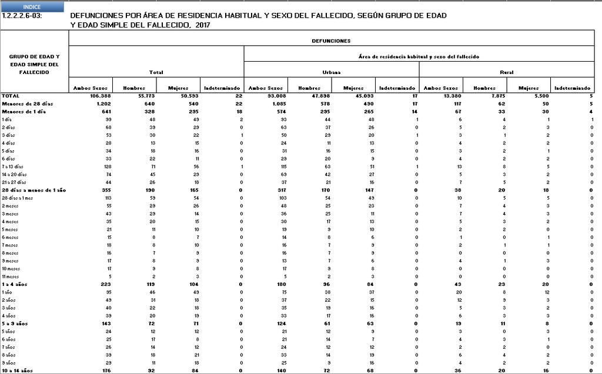

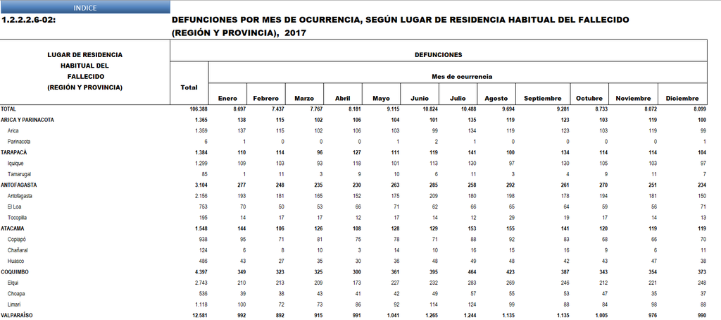

https://www.ine.cl/estadisticas/sociales/demografia-y-vitales/nacimientos-matrimonios-y-defunciones

## 1.3 Promedio de educación

```r
casen_2020 <<- readRDS("C:/Users/chris/OneDrive/Documentos/archivos_grandes/casen_2020_e1.rds")
casen_2020 <- mutate_if(casen_2020, is.factor, as.character)

prome_educ <- casen_2020[,c("comuna","edad","esc2")]
prome_educ <- filter(prome_educ, edad > 15)
prome_educ <- prome_educ[!is.na(prome_educ[,c("esc2")]),]


comunas <- unique(prome_educ$comuna)

promedios <- data.frame()

for (i in comunas) {

  filtro <- filter(prome_educ, comuna == i)
  calculo_prom <- data.frame(
  comuna = i,
  prom_educ = mean(filtro$esc2)
)
promedios <- rbind(promedios,calculo_prom)
}

datatable(promedios)
```

|  | comuna | prom_educ |
| --- | --- | --- |
| 1 | Iquique | 12.5351651121754 |
| 2 | Alto Hospicio | 11.3009086050241 |
| 3 | Pozo Almonte | 11.5443037974684 |
| 4 | Camiña | 7.90322580645161 |
| 5 | Huara | 9.76363636363636 |
| 6 | Pica | 11.2620689655172 |
| 7 | Antofagasta | 12.3605461131234 |
| 8 | Mejillones | 11.4318181818182 |
| 9 | Sierra Gorda | 11 |
| 10 | Taltal | 10.4914285714286 |

[output cut: 314 more lines]

https://public.tableau.com/app/profile/deis4231/viz/Anuario_Defunciones/Defunciones

https://www.lifeexpectancy.org/help/1.0/The%20Life%20Table.shtml